# Applied Statistics_Balraj

```python
import warnings
warnings.filterwarnings('ignore')
warnings.warn('DelftStack')
warnings.warn('Do not show this message')
print("No Warning Shown")
```

```
No Warning Shown
```

```python
#1. Please refer the table below to answer below questions: [2 Marks]
```

[output not shown]

```python
#1.A. Refer above table and find the joint probability of the people who planned to purchase and actually placed an order. [1 Mark]

400/2000
```

```
0.2
```

```python
#1.B. Refer to the above table and find the joint probability of the people who planned to purchase and actually placed an order, given that
#people planned to purchase.

400/500
```

```
0.8
```

# 2. An electrical manufacturing company conducts quality checks at specified periods on the products it manufactures. Historically, the failure rate for the manufactured item is 5%. Suppose a random sample of 10 manufactured items is selected. Answer the following questions. [4 Marks]

```python
import scipy.stats as stats
import numpy as np
```

```python
k =np.arange(0,10)
n = 10
p = 0.05
a = stats.binom.pmf(k,n,p)
```

```python
#2.A. Probability that none of the items are defective? [1 Mark]

print("Probability that none of the items are defective is " +  str(a[0]))
```

```
Probability that none of the items are defective is 0.5987369392383789
```

```python
#2.B. Probability that exactly one of the items is defective? [1 Mark]

print("Probability that exactly one of the items is defective is " +  str(a[1]))
```

```
Probability that exactly one of the items is defective is 0.31512470486230504
```

```python
cumulative = stats.binom.cdf(k,n,p)
```

```python
#2.C. Probability that two or fewer of the items are defective? [1 Mark]

print("Probability that two or fewer of the items are defective is " +  str(cumulative[2]))
```

```
Probability that two or fewer of the items are defective is 0.9884964426207031
```

# 3. A car salesman sells on an average 3 cars per week. [3 Marks]

```python
#3.A. What is Probability that in a given week he will sell some cars? [1 Mark]

n=np.arange(0,10)
m = 3
carsales = stats.poisson.cdf(n,m)

print("" +  str(1 - carsales[0]))
```

```
0.950212931632136
```

```python
#3.B. What is Probability that in a given week he will sell 2 or more but less than 5 cars? [1 Mark]

cusales = stats.poisson.cdf(n,m)

print("" +  str(cusales[4] - cusales[1]) )
```

```
0.6161149710523164
```

```python
import matplotlib.pyplot as plt
```

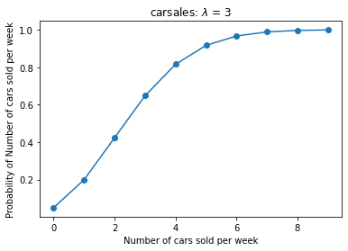

```python
#3.C. Plot the poisson distribution function for cumulative probability of cars sold per-week vs number of cars sold per week. [1 Mark]

plt.plot(n,cusales,'o-')
plt.title('carsales: $\lambda$ = %i ' % m)
plt.xlabel('Number of cars sold per week')
plt.ylabel('Probability of Number of cars sold per week')
plt.show()
```

# 4. Accuracy in understanding orders for a speech based bot at a restaurant is important for the Company X which has designed,marketed and launched the product for a contactless delivery due to the COVID-19 pandemic. Recognition accuracy that measures the percentage of orders that are taken correctly is 86.8%. Suppose that you place an order with the bot and two friends of yoursindependently place orders with the same bot. Answer the following questions. [3 Marks]

```python
#4.A. What is the probability that all three orders will be recognised correctly? [1 Mark]

i=np.arange(0,5)
n =3
p = 0.868
data = stats.binom.pmf(i,n,p)
print("probability that all three orders will be recognised correctly is" +  str(data[3]))
```

```
probability that all three orders will be recognised correctly is0.653972032
```

```python
#4.B. What is the probability that none of the three orders will be recognised correctly? [1 Mark]

print("probability that none of the three orders will be recognised correctly is " +  str(data[0]))
```

```
probability that none of the three orders will be recognised correctly is 0.002299968
```

```python
#4.C. What is the probability that at least two of the three orders will be recognised correctly? [1 Mark]

print("probability that at least two of the three orders will be recognised correctly is " + str(1-(data[0] + data[1])))
```

```
probability that at least two of the three orders will be recognised correctly is 0.952327936
```

# 5. Explain 1 real life industry scenario (other than the ones mentioned above) where you can use the concepts learnt in this module of Applied Statistics to get data driven business solution. [3 Marks]

One of the best examples where Statistics used to drive business is Travel & Tourism.

Following are the reasearchs that are related to the travel & tourism inustries:

```
-How much people spend during the travel.
-Type of people who travel.
-What are the most visiting place where people go and when they usually travel such as hill stations, beach, islands, etc.
-Factors affecting the decision of travel and its reason such as to relax, make memories, adventure, etc.
-Apart from travel, what other things people used to do.
-Marketing channels, stategies, and tactics for increase the return.
-Prepare budgets and spend statistics.
-How pandemic like Covid-19 affect the business and what will be the ecsape plan
```

# Part B - 30 Marks

• DOMAIN: Sports • CONTEXT: Company X manages the men's top professional basketball division of the American league system. The dataset contains information on all the teams that have participated in all the past tournaments. It has data about how many baskets each team scored, conceded, how many times they came within the first 2 positions, how many tournaments they have qualified, their best position in the past, etc. • DATA DESCRIPTION: Basketball.csv - The data set contains information on all the teams so far participated in all the past tournaments. • DATA DICTIONARY:

1. Team: Team’s name
2. Tournament: Number of played tournaments.
3. Score: Team’s score so far.
4. PlayedGames: Games played by the team so far.
5. WonGames: Games won by the team so far.
6. DrawnGames: Games drawn by the team so far.
7. LostGames: Games lost by the team so far.
8. BasketScored: Basket scored by the team so far.
9. BasketGiven: Basket scored against the team so far.
10. TournamentChampion: How many times the team was a champion of the tournaments so far.
11. Runner-up: How many times the team was a runners-up of the tournaments so far.
12. TeamLaunch: Year the team was launched on professional basketball.
13. HighestPositionHeld: Highest position held by the team amongst all the tournaments played. • PROJECT OBJECTIVE: Company’s management wants to invest on proposals on managing some of the best teams in the league. The analytics department has been assigned with a task of creating a report on the performance shown by the teams. Some of the older teams are already in contract with competitors. Hence Company X wants to understand which teams they can approach which will be a deal win for them.

# • STEPS AND TASK [30 Marks]:

```python
#1. Read the data set, clean the data and prepare final dataset to be used for analysis. [10 Marks]

# import neccessary packages for data handling

import os
import pandas as pd

# import neccessary packages for plots and visualizations

import seaborn as sns
%matplotlib inline
```

```python
path = os.chdir('C:\\Users\\bgj\\Desktop\\GreatLearning-Appliedstatistics')
dataset = pd.read_csv('Basketball.csv')
dataset.head()
```

|  | Team | Tournament | Score | PlayedGames | WonGames | DrawnGames | LostGames | BasketScored | BasketGiven | TournamentChampion | Runner-up | TeamLaunch | HighestPositionHeld |
| --- | --- | --- | --- | --- | --- | --- | --- | --- | --- | --- | --- | --- | --- |
| 0 | Team 1 | 86 | 4385 | 2762 | 1647 | 552 | 563 | 5947 | 3140 | 33 | 23 | 1929 | 1 |
| 1 | Team 2 | 86 | 4262 | 2762 | 1581 | 573 | 608 | 5900 | 3114 | 25 | 25 | 1929 | 1 |
| 2 | Team 3 | 80 | 3442 | 2614 | 1241 | 598 | 775 | 4534 | 3309 | 10 | 8 | 1929 | 1 |
| 3 | Team 4 | 82 | 3386 | 2664 | 1187 | 616 | 861 | 4398 | 3469 | 6 | 6 | 1931to32 | 1 |
| 4 | Team 5 | 86 | 3368 | 2762 | 1209 | 633 | 920 | 4631 | 3700 | 8 | 7 | 1929 | 1 |

```python
# 1. replacing "-" to 0
dataset.replace('-', 0,inplace=True)
```

```python
#2. teamlaunch column converted into only year - "YYYY"

dataset['LaunchYear'] = dataset['TeamLaunch'].str[:4]
dataset = dataset.drop(['TeamLaunch'], axis =1)
```

```python
# lets check the data now

dataset.head()
```

|  | Team | Tournament | Score | PlayedGames | WonGames | DrawnGames | LostGames | BasketScored | BasketGiven | TournamentChampion | Runner-up | HighestPositionHeld | LaunchYear |
| --- | --- | --- | --- | --- | --- | --- | --- | --- | --- | --- | --- | --- | --- |
| 0 | Team 1 | 86 | 4385 | 2762 | 1647 | 552 | 563 | 5947 | 3140 | 33 | 23 | 1 | 1929 |
| 1 | Team 2 | 86 | 4262 | 2762 | 1581 | 573 | 608 | 5900 | 3114 | 25 | 25 | 1 | 1929 |
| 2 | Team 3 | 80 | 3442 | 2614 | 1241 | 598 | 775 | 4534 | 3309 | 10 | 8 | 1 | 1929 |
| 3 | Team 4 | 82 | 3386 | 2664 | 1187 | 616 | 861 | 4398 | 3469 | 6 | 6 | 1 | 1931 |
| 4 | Team 5 | 86 | 3368 | 2762 | 1209 | 633 | 920 | 4631 | 3700 | 8 | 7 | 1 | 1929 |

```python
# check the column names and data types

dataset.info()
```

```
<class 'pandas.core.frame.DataFrame'>
RangeIndex: 61 entries, 0 to 60
Data columns (total 13 columns):
 #   Column               Non-Null Count  Dtype
---  ------               --------------  -----
 0   Team                 61 non-null     object
 1   Tournament           61 non-null     int64
 2   Score                61 non-null     object
 3   PlayedGames          61 non-null     object
 4   WonGames             61 non-null     object
 5   DrawnGames           61 non-null     object
 6   LostGames            61 non-null     object
 7   BasketScored         61 non-null     object
 8   BasketGiven          61 non-null     object
 9   TournamentChampion   61 non-null     object
 10  Runner-up            61 non-null     object
 11  HighestPositionHeld  61 non-null     int64
 12  LaunchYear           61 non-null     object
dtypes: int64(2), object(11)
memory usage: 6.3+ KB
```

```python
# rename the column
dataset = dataset.rename(columns = {'Runner-up': 'RunnerUp'})
```

```python
# 3. converting all column to int except team column

dataset.columns
dataset['Tournament'] = dataset['Tournament'].astype('int')
dataset['Score'] = dataset['Score'].astype('int')
dataset['WonGames'] = dataset['WonGames'].astype('int')
dataset['DrawnGames'] = dataset['DrawnGames'].astype('int')
dataset['LostGames'] = dataset['LostGames'].astype('int')
dataset['BasketScored'] = dataset['BasketScored'].astype('int')
dataset['TournamentChampion'] = dataset['TournamentChampion'].astype('int')
dataset['RunnerUp'] = dataset['RunnerUp'].astype('int')
dataset['LaunchYear'] = dataset['LaunchYear'].astype('int')
dataset['HighestPositionHeld'] = dataset['HighestPositionHeld'].astype('int')
dataset['PlayedGames'] = dataset['PlayedGames'].astype('int')
dataset['BasketGiven'] = dataset['BasketGiven'].astype('int')
```

```python
# 4 however, we could see in data for team 61 there is no meayse, hence I am removing that row for our analysis

dataset.drop(dataset[dataset.Score <= 0].index, inplace=True)

dataset.info()
```

```
<class 'pandas.core.frame.DataFrame'>
Int64Index: 60 entries, 0 to 59
Data columns (total 13 columns):
 #   Column               Non-Null Count  Dtype
---  ------               --------------  -----
 0   Team                 60 non-null     object
 1   Tournament           60 non-null     int32
 2   Score                60 non-null     int32
 3   PlayedGames          60 non-null     int32
 4   WonGames             60 non-null     int32
 5   DrawnGames           60 non-null     int32
 6   LostGames            60 non-null     int32
 7   BasketScored         60 non-null     int32
 8   BasketGiven          60 non-null     int32
 9   TournamentChampion   60 non-null     int32
 10  RunnerUp             60 non-null     int32
 11  HighestPositionHeld  60 non-null     int32
 12  LaunchYear           60 non-null     int32
dtypes: int32(12), object(1)
memory usage: 3.8+ KB
```

```python
dataset.head(20)
```

|  | Team | Tournament | Score | PlayedGames | WonGames | DrawnGames | LostGames | BasketScored | BasketGiven | TournamentChampion | RunnerUp | HighestPositionHeld | LaunchYear |
| --- | --- | --- | --- | --- | --- | --- | --- | --- | --- | --- | --- | --- | --- |
| 0 | Team 1 | 86 | 4385 | 2762 | 1647 | 552 | 563 | 5947 | 3140 | 33 | 23 | 1 | 1929 |
| 1 | Team 2 | 86 | 4262 | 2762 | 1581 | 573 | 608 | 5900 | 3114 | 25 | 25 | 1 | 1929 |
| 2 | Team 3 | 80 | 3442 | 2614 | 1241 | 598 | 775 | 4534 | 3309 | 10 | 8 | 1 | 1929 |
| 3 | Team 4 | 82 | 3386 | 2664 | 1187 | 616 | 861 | 4398 | 3469 | 6 | 6 | 1 | 1931 |
| 4 | Team 5 | 86 | 3368 | 2762 | 1209 | 633 | 920 | 4631 | 3700 | 8 | 7 | 1 | 1929 |
| 5 | Team 6 | 73 | 2819 | 2408 | 990 | 531 | 887 | 3680 | 3373 | 1 | 4 | 1 | 1934 |
| 6 | Team 7 | 82 | 2792 | 2626 | 948 | 608 | 1070 | 3609 | 3889 | 0 | 0 | 3 | 1929 |
| 7 | Team 8 | 70 | 2573 | 2302 | 864 | 577 | 861 | 3228 | 3230 | 2 | 3 | 1 | 1929 |
| 8 | Team 9 | 58 | 2109 | 1986 | 698 | 522 | 766 | 2683 | 2847 | 0 | 1 | 2 | 1939 |
| 9 | Team 10 | 51 | 1884 | 1728 | 606 | 440 | 682 | 2159 | 2492 | 1 | 0 | 1 | 1932 |
| 10 | Team 11 | 45 | 1814 | 1530 | 563 | 392 | 575 | 2052 | 2188 | 1 | 5 | 1 | 1941 |
| 11 | Team 12 | 51 | 1789 | 1698 | 586 | 389 | 723 | 2278 | 2624 | 0 | 0 | 4 | 1939 |
| 12 | Team 13 | 42 | 1471 | 1466 | 463 | 384 | 619 | 1767 | 2180 | 0 | 0 | 4 | 1948 |
| 13 | Team 14 | 44 | 1416 | 1428 | 453 | 336 | 639 | 1843 | 2368 | 0 | 1 | 2 | 1929 |
| 14 | Team 15 | 43 | 1389 | 1458 | 471 | 358 | 629 | 1753 | 2152 | 0 | 1 | 2 | 1944 |
| 15 | Team 16 | 37 | 1351 | 1318 | 426 | 327 | 565 | 1500 | 1834 | 0 | 0 | 4 | 1935 |
| 16 | Team 17 | 36 | 1314 | 1255 | 390 | 330 | 535 | 1421 | 1763 | 0 | 0 | 4 | 1949 |
| 17 | Team 18 | 38 | 1174 | 1192 | 408 | 292 | 492 | 1642 | 1951 | 0 | 0 | 3 | 1933 |
| 18 | Team 19 | 27 | 1148 | 988 | 333 | 256 | 399 | 1182 | 1371 | 0 | 0 | 3 | 1960 |
| 19 | Team 20 | 33 | 1020 | 1096 | 367 | 242 | 487 | 1347 | 1746 | 0 | 1 | 2 | 1951 |

```python
dataset.describe(include = 'all').round(0).T
```

|  | count | unique | top | freq | mean | std | min | 25% | 50% | 75% | max |
| --- | --- | --- | --- | --- | --- | --- | --- | --- | --- | --- | --- |
| Team | 60 | 60 | Team 1 | 1 | NaN | NaN | NaN | NaN | NaN | NaN | NaN |
| Tournament | 60.0 | NaN | NaN | NaN | 24.0 | 27.0 | 1.0 | 4.0 | 12.0 | 39.0 | 86.0 |
| Score | 60.0 | NaN | NaN | NaN | 916.0 | 1138.0 | 14.0 | 104.0 | 396.0 | 1360.0 | 4385.0 |
| PlayedGames | 60.0 | NaN | NaN | NaN | 810.0 | 877.0 | 30.0 | 116.0 | 424.0 | 1346.0 | 2762.0 |
| WonGames | 60.0 | NaN | NaN | NaN | 309.0 | 408.0 | 5.0 | 35.0 | 124.0 | 433.0 | 1647.0 |
| DrawnGames | 60.0 | NaN | NaN | NaN | 192.0 | 202.0 | 4.0 | 26.0 | 98.0 | 332.0 | 633.0 |
| LostGames | 60.0 | NaN | NaN | NaN | 309.0 | 295.0 | 15.0 | 63.0 | 198.0 | 564.0 | 1070.0 |
| BasketScored | 60.0 | NaN | NaN | NaN | 1159.0 | 1512.0 | 34.0 | 154.0 | 444.0 | 1670.0 | 5947.0 |
| BasketGiven | 60.0 | NaN | NaN | NaN | 1159.0 | 1164.0 | 55.0 | 236.0 | 632.0 | 2001.0 | 3889.0 |
| TournamentChampion | 60.0 | NaN | NaN | NaN | 1.0 | 6.0 | 0.0 | 0.0 | 0.0 | 0.0 | 33.0 |
| RunnerUp | 60.0 | NaN | NaN | NaN | 1.0 | 5.0 | 0.0 | 0.0 | 0.0 | 0.0 | 25.0 |
| HighestPositionHeld | 60.0 | NaN | NaN | NaN | 7.0 | 5.0 | 1.0 | 3.0 | 6.0 | 10.0 | 20.0 |
| LaunchYear | 60.0 | NaN | NaN | NaN | 1958.0 | 27.0 | 1929.0 | 1935.0 | 1950.0 | 1977.0 | 2016.0 |

```python
dataset.describe()
```

|  | Tournament | Score | PlayedGames | WonGames | DrawnGames | LostGames | BasketScored | BasketGiven | TournamentChampion | RunnerUp | HighestPositionHeld | LaunchYear |
| --- | --- | --- | --- | --- | --- | --- | --- | --- | --- | --- | --- | --- |
| count | 60.000000 | 60.000000 | 60.000000 | 60.000000 | 60.000000 | 60.000000 | 60.000000 | 60.000000 | 60.00000 | 60.000000 | 60.000000 | 60.000000 |
| mean | 24.383333 | 916.450000 | 810.100000 | 309.033333 | 192.083333 | 308.816667 | 1159.350000 | 1159.233333 | 1.45000 | 1.433333 | 7.050000 | 1957.950000 |
| std | 26.884620 | 1138.342899 | 877.465393 | 408.481395 | 201.985508 | 294.508639 | 1512.063948 | 1163.946914 | 5.51554 | 4.574679 | 5.315232 | 26.646732 |
| min | 1.000000 | 14.000000 | 30.000000 | 5.000000 | 4.000000 | 15.000000 | 34.000000 | 55.000000 | 0.00000 | 0.000000 | 1.000000 | 1929.000000 |
| 25% | 4.000000 | 104.250000 | 115.500000 | 34.750000 | 26.250000 | 62.750000 | 154.500000 | 236.000000 | 0.00000 | 0.000000 | 3.000000 | 1934.750000 |
| 50% | 12.000000 | 395.500000 | 424.500000 | 124.000000 | 98.500000 | 197.500000 | 444.000000 | 632.500000 | 0.00000 | 0.000000 | 6.000000 | 1950.500000 |
| 75% | 39.000000 | 1360.500000 | 1345.500000 | 432.750000 | 331.500000 | 563.500000 | 1669.750000 | 2001.250000 | 0.00000 | 0.000000 | 10.000000 | 1977.250000 |
| max | 86.000000 | 4385.000000 | 2762.000000 | 1647.000000 | 633.000000 | 1070.000000 | 5947.000000 | 3889.000000 | 33.00000 | 25.000000 | 20.000000 | 2016.000000 |

# Preparing Final Data with few measure columns

1. Tournament Win Percentage
2. Win Percentage
3. Runner up Percentage
4. Lost percentage

```python
#1. Tournament Win Percentage

tour = dataset['TournamentChampion'] / dataset['Tournament']
dataset.insert(loc=3, column='Tourwinpct', value=tour)
```

```python
#2. Win Percentage

winpct = dataset['WonGames'] / dataset['PlayedGames']
dataset.insert(loc=6, column='WinningPct', value=winpct)
```

```python
#3. Runner up Percentage

runpct = dataset['RunnerUp'] / dataset['Tournament']
dataset.insert(loc=13, column='RunUpPct', value=runpct)
```

```python
# 4. Lost percentage

lostpct = dataset['LostGames'] / dataset['PlayedGames']
dataset.insert(loc=9, column='Lostpct', value=lostpct)
```

```python
dataset.head()
```

|  | Team | Tournament | Score | Tourwinpct | PlayedGames | WonGames | WinningPct | DrawnGames | LostGames | Lostpct | BasketScored | BasketGiven | TournamentChampion | RunnerUp | RunUpPct | HighestPositionHeld | LaunchYear |
| --- | --- | --- | --- | --- | --- | --- | --- | --- | --- | --- | --- | --- | --- | --- | --- | --- | --- |
| 0 | Team 1 | 86 | 4385 | 0.383721 | 2762 | 1647 | 0.596307 | 552 | 563 | 0.203838 | 5947 | 3140 | 33 | 23 | 0.267442 | 1 | 1929 |
| 1 | Team 2 | 86 | 4262 | 0.290698 | 2762 | 1581 | 0.572411 | 573 | 608 | 0.220130 | 5900 | 3114 | 25 | 25 | 0.290698 | 1 | 1929 |
| 2 | Team 3 | 80 | 3442 | 0.125000 | 2614 | 1241 | 0.474751 | 598 | 775 | 0.296480 | 4534 | 3309 | 10 | 8 | 0.100000 | 1 | 1929 |
| 3 | Team 4 | 82 | 3386 | 0.073171 | 2664 | 1187 | 0.445571 | 616 | 861 | 0.323198 | 4398 | 3469 | 6 | 6 | 0.073171 | 1 | 1931 |
| 4 | Team 5 | 86 | 3368 | 0.093023 | 2762 | 1209 | 0.437726 | 633 | 920 | 0.333092 | 4631 | 3700 | 8 | 7 | 0.081395 | 1 | 1929 |

# 2. Perform detailed statistical analysis and EDA using univariate, bi-variate and multivariate EDA techniques to get data driven insights on recommending which teams they can approach which will be a deal win for them. Also as a data and statistics expert you have to develop a detailed performance report using this data. [10 Marks]

Hint: Use statistical techniques and visualisation techniques to come up with useful metrics and reporting. Find out the best performing team, oldest team, team with highest goals, team with lowest performance etc. and many more. These are just random examples. Please use your best analytical approach to build this report. You can mix match columns to create new ones which can be used for better analysis. Create your own features if required. Be highly experimental and analytical here to find hidden patterns. Use graphical interactive libraries to enable you to publish interactive plots in python.

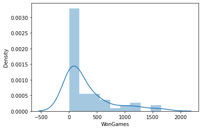

```python
# 1. Univariate Analysis

sns.distplot(dataset['WonGames'])
plt.show()
```

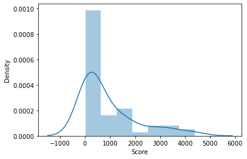

```python
sns.distplot(dataset['Score'])
plt.show()
```

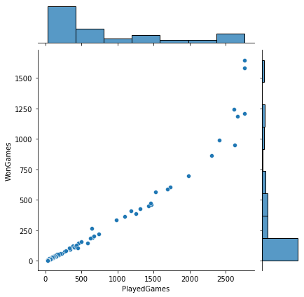

```python
# 2. Bivariate Analysis

# No of tournaments played by teams

sns.jointplot(dataset['PlayedGames'], dataset['WonGames']);
```

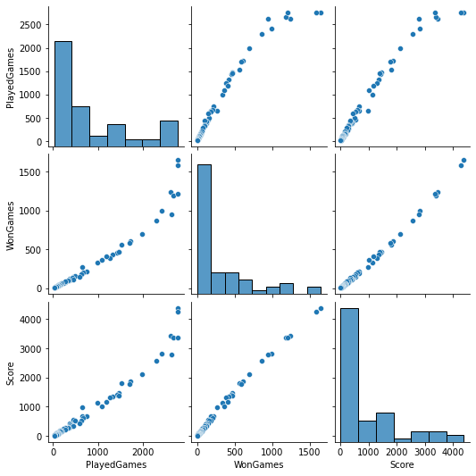

```python
#Pairwise distribustion

sns.pairplot(dataset[['PlayedGames', 'WonGames', 'Score']]);
```

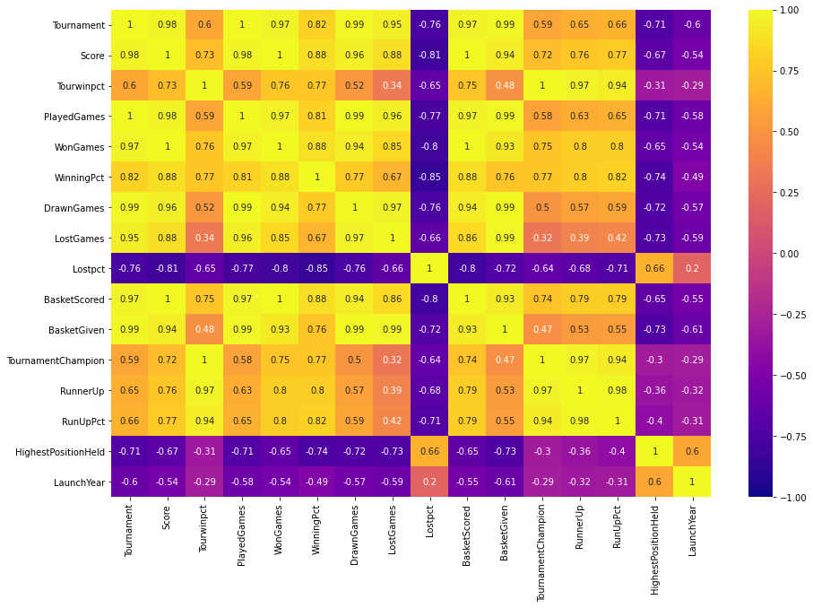

```python
# For complete data
# use correlation matrix

corr = dataset.corr()
plt.subplots(figsize=(15,10))
sns.heatmap(corr,annot=True,cmap='plasma',vmin=-1,vmax=1)
```

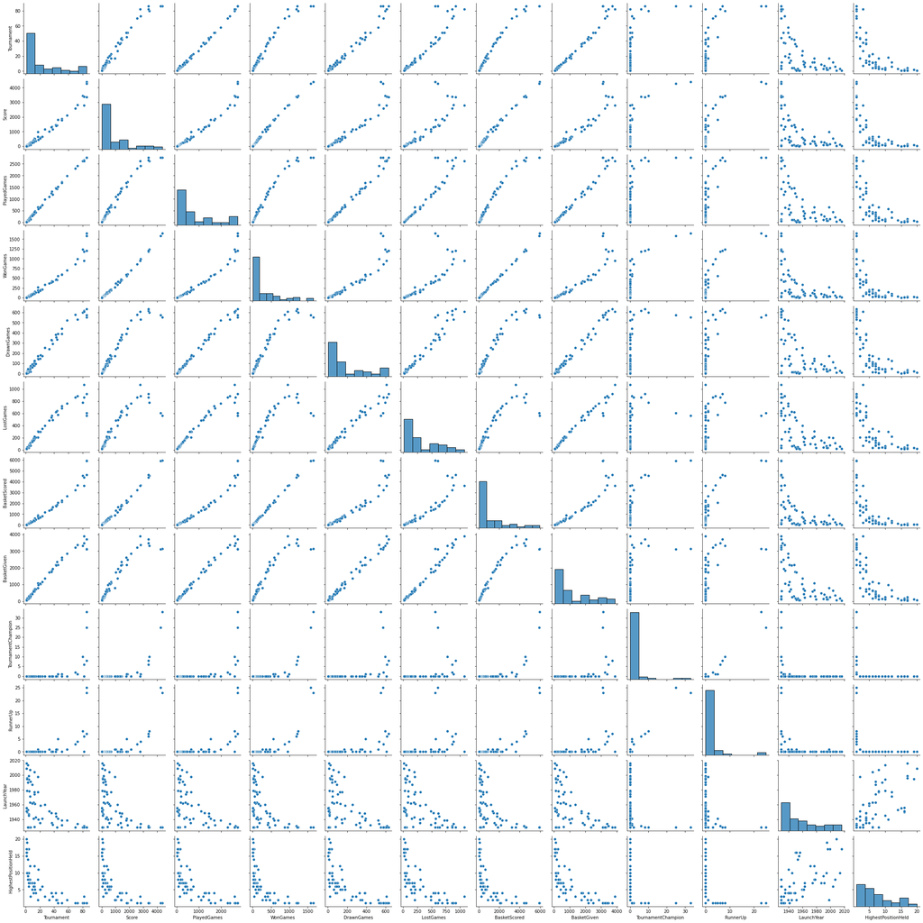

```python
# 1.MultiVariate Analysis

finallist = ['Tournament','Score','PlayedGames','WonGames','DrawnGames','LostGames','BasketScored','BasketGiven','TournamentChampion','RunnerUp','LaunchYear','HighestPositionHeld']

sns.pairplot(dataset[finallist])
```

[output not shown]

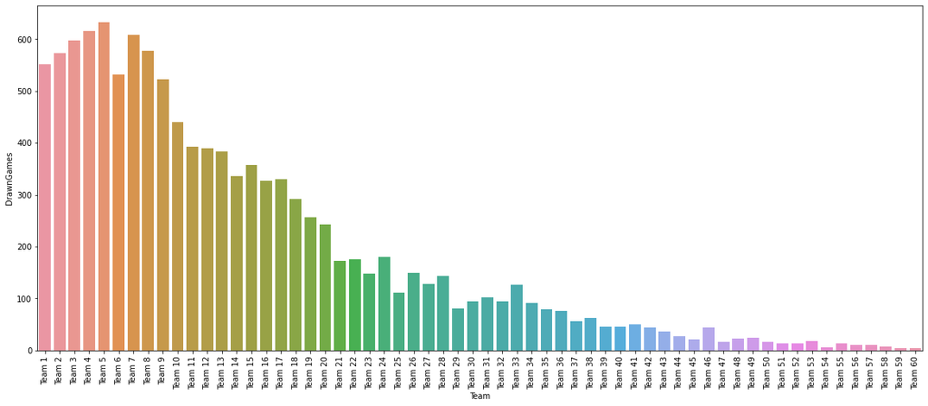

```python
plt.figure(figsize=(20,8))
sns.barplot(dataset['Team'], dataset['DrawnGames'])
plt.xticks(rotation=90)
```

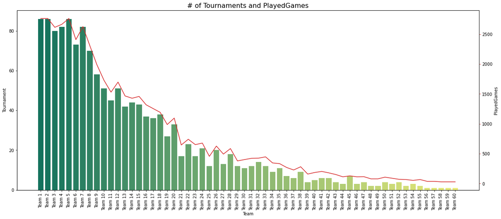

```python
#Combined Chart & Observation
fig, ax1 = plt.subplots(figsize=(20,8))
color = 'tab:green'
#bar plot creation
ax1.set_title('# of Tournaments and PlayedGames', fontsize=16)
plt.xticks(rotation=90)
ax1 = sns.barplot(x='Team', y='Tournament', data = dataset, palette='summer')
ax1.tick_params(axis='y')
#specify we want to share the same x-axis
ax2 = ax1.twinx()
color = 'tab:red'
#line plot creation
ax2 = sns.lineplot(x='Team', y='PlayedGames', data = dataset, sort=False, color=color)
ax2.tick_params(axis='y', color=color)
#show plot
plt.show()
```

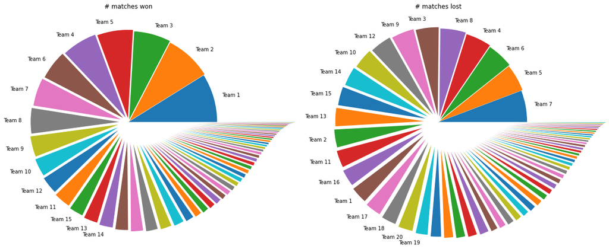

```python
# No of matches won/lost by teams
plt.figure(figsize=(20,8))
plt.subplot(1,2,1)
bb = dataset[['Team','WonGames']].sort_values(by="WonGames", ascending=False)
plot = plt.pie(bb['WonGames'], labels=list(bb['Team'][:15]) + [str()] * (len(bb)-15), explode=[0.015*x for x in range(len(bb))])
plt.title('# matches won')
plt.subplot(1,2,2)
bb = dataset[['Team','LostGames']].sort_values(by="LostGames", ascending=False)
plot = plt.pie(bb['LostGames'], labels=list(bb['Team'][:20]) + [str()] * (len(bb)-20), explode=[0.015*x for x in range(len(bb))])
plt.title('# matches lost')
```

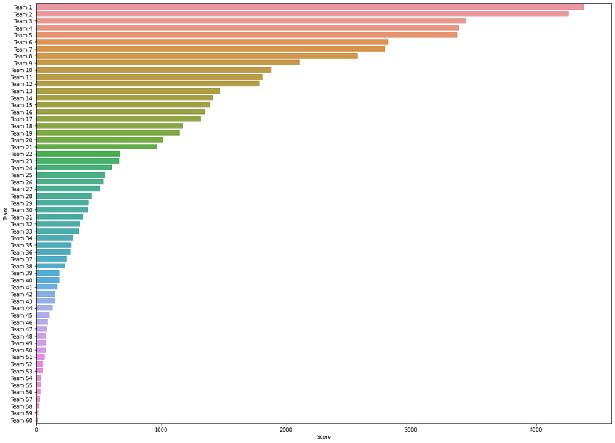

```python
# Scores of the teams
plt.figure(figsize=(20,15))
sns.barplot(dataset['Score'], dataset['Team'], orient='h')
```

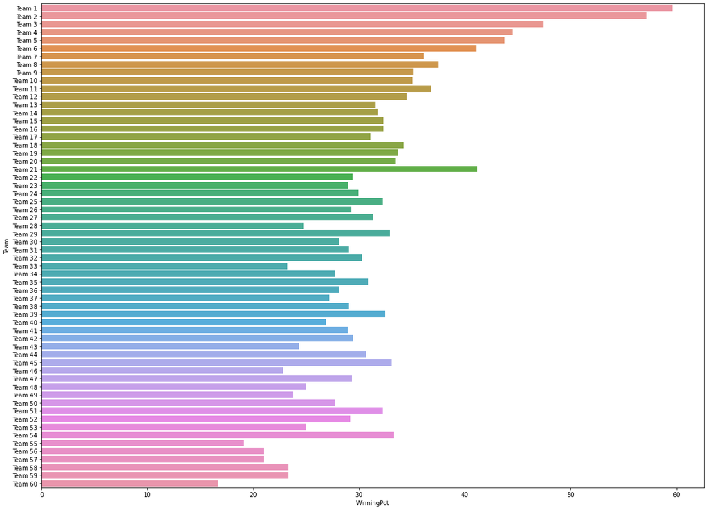

```python
# Win Percentage of the teams
plt.figure(figsize=(20,15))
sns.barplot(dataset['WinningPct'] * 100, dataset['Team'], orient='h')
```

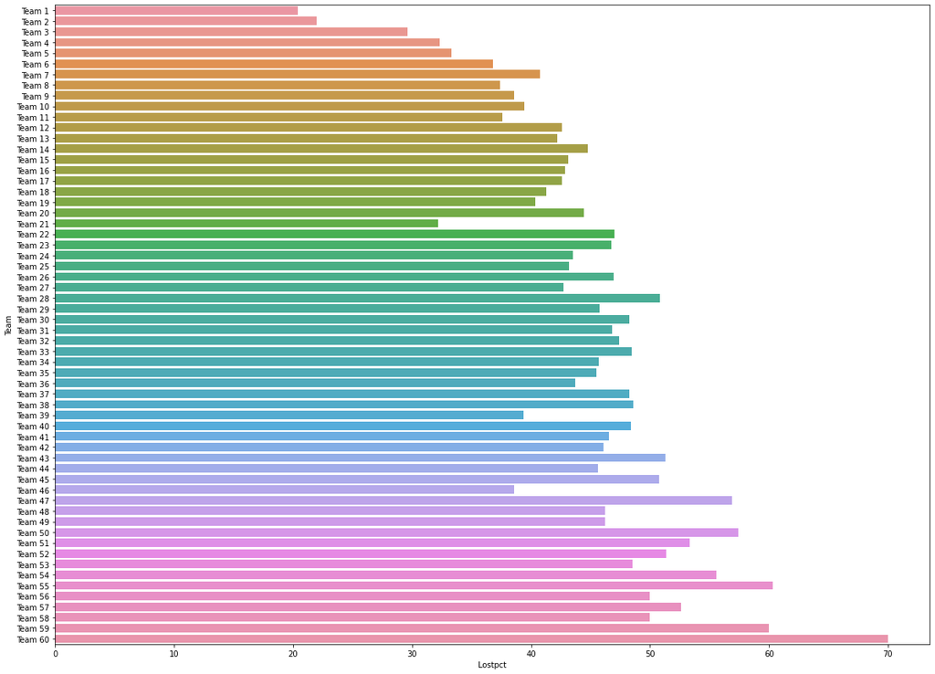

```python
# Lost Percentage of the teams
plt.figure(figsize=(20,15))
sns.barplot(dataset['Lostpct'] * 100, dataset['Team'], orient='h')
```

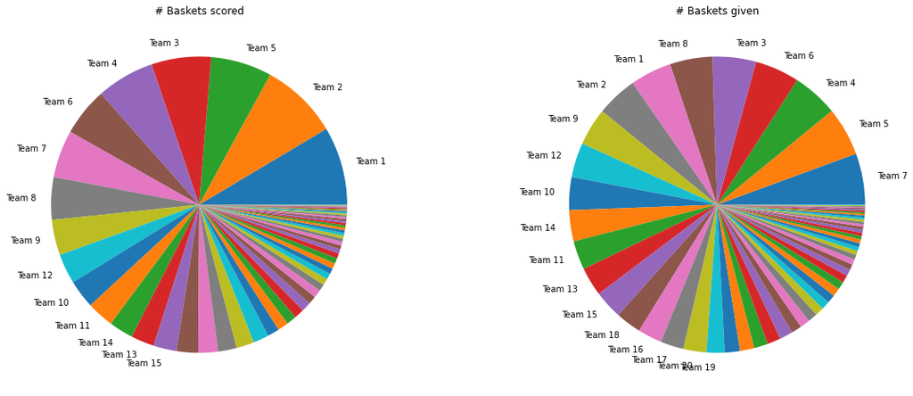

```python
# No of baskets scored/given by teams
plt.figure(figsize=(20,8))
plt.subplot(1,2,1)
bb = dataset[['Team','BasketScored']].sort_values(by="BasketScored", ascending=False)
plot = plt.pie(bb['BasketScored'], labels=list(bb['Team'][:15]) + [str()] * (len(bb)-15))
plt.title('# Baskets scored')
plt.subplot(1,2,2)
bb = dataset[['Team','BasketGiven']].sort_values(by="BasketGiven", ascending=False)
plot = plt.pie(bb['BasketGiven'], labels=list(bb['Team'][:20]) + [str()] * (len(bb)-20))
plt.title('# Baskets given')
```

[output not shown]

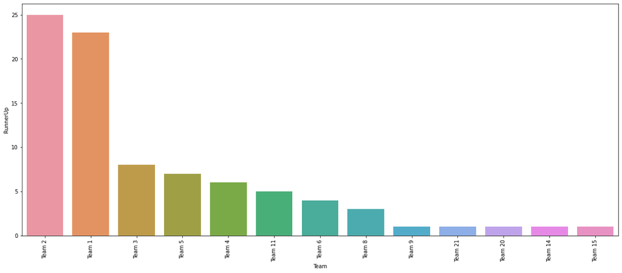

```python
# The most runner-up
plt.figure(figsize=(20,8))
bb = dataset[['Team','RunnerUp']].sort_values(by="RunnerUp", ascending=False).where(lambda x: x["RunnerUp"] > 0)
sns.barplot(bb['Team'], bb['RunnerUp'])
plt.xticks(rotation=90)
```

# Although teams 9, 14, 15, 20, and 21 never won any tournament but being in the final game with higher rate of Win, there is chance that these teams can also win the tournament and if other teams are already in contract with competitors, Company X can approach these teams also.

# Please include any improvements or suggestions to the association management on quality, quantity, variety, velocity, veracity etc. on thedata points collected by the association to perform a better data analysis in future. At-least 1 suggestion for each point. [10 Marks]

Suggestions to the association managemnet on the data points collected. -Please include total fouls made by team, total goals of the opponent due to three consecutive fouls. -Please include min, max, and average age of players. -Please include Average Efficiency of the players. -Players profilers(age, number of games played) -Players awards -Players Ranking

# Part C - 15 Marks

• DOMAIN: Startup ecosystem • CONTEXT: Company X is a EU online publisher focusing on the startups industry. The company specifically reports on the business related to technology news, analysis of emerging trends and profiling of new tech businesses and products. Their event i.e. Startup Battlefield is the world’s pre-eminent startup competition. Startup Battlefield features 15-30 top early stage startups pitching top judges in front of a vast live audience, present in person and online. • DATA DESCRIPTION: CompanyX_EU.csv - Each row in the dataset is a Start-up company and the columns describe the company. • DATA DICTIONARY:

1. Startup: Name of the company
2. Product: Actual product
3. Funding: Funds raised by the company in USD
4. Event: The event the company participated in
5. Result: Described by Contestant, Finalist, Audience choice, Winner or Runner up
6. OperatingState: Current status of the company, Operating ,Closed, Acquired or IPO *Dataset has been downloaded from the internet. All the credit for the dataset goes to the original creator of the data. • PROJECT OBJECTIVE: Analyse the data of the various companies from the given dataset and perform the tasks that are specified in the below steps. Draw insights from the various attributes that are present in the dataset, plot distributions, state hypotheses and draw conclusions from the dataset.

# 1. read csv file

```python
df = pd.read_csv('CompanyX_EU.csv')
```

```python
df.info()
```

```
<class 'pandas.core.frame.DataFrame'>
RangeIndex: 662 entries, 0 to 661
Data columns (total 6 columns):
 #   Column          Non-Null Count  Dtype
---  ------          --------------  -----
 0   Startup         662 non-null    object
 1   Product         656 non-null    object
 2   Funding         448 non-null    object
 3   Event           662 non-null    object
 4   Result          662 non-null    object
 5   OperatingState  662 non-null    object
dtypes: object(6)
memory usage: 31.2+ KB
```

# 2. Data Exploration: [1 Mark]

```python
#A. Check the datatypes of each attribute.

df.dtypes
```

```
Startup           object
Product           object
Funding           object
Event             object
Result            object
OperatingState    object
dtype: object
```

```python
#B. Check for null values in the attributes.

df.isnull().sum()
```

```
Startup             0
Product             6
Funding           214
Event               0
Result              0
OperatingState      0
dtype: int64
```

# 3. Data preprocessing & visualisation: [4 Marks]

```python
#A. Drop the null values. [1 Mark]

df = df.dropna()
```

```python
df.info()
```

```
<class 'pandas.core.frame.DataFrame'>
Int64Index: 446 entries, 1 to 661
Data columns (total 6 columns):
 #   Column          Non-Null Count  Dtype
---  ------          --------------  -----
 0   Startup         446 non-null    object
 1   Product         446 non-null    object
 2   Funding         446 non-null    object
 3   Event           446 non-null    object
 4   Result          446 non-null    object
 5   OperatingState  446 non-null    object
dtypes: object(6)
memory usage: 24.4+ KB
```

```python
# check null values
df.isnull().sum()
```

```
Startup           0
Product           0
Funding           0
Event             0
Result            0
OperatingState    0
dtype: int64
```

```python
# lets check the column 'Funding'

df['Funding'].head()
```

```
1      $630K
3        $1M
5     $19.3M
6       $29M
10     $1.8M
Name: Funding, dtype: object
```

```python
#B. Convert the ‘Funding’ features to a numerical value.

df.loc[:,'Funds_in_million'] = df['Funding'].apply(lambda x: float(x[1:-1])/1000 if x[-1] == 'K' else (float(x[1:-1])*1000 if x[-1] == 'B' else float(x[1:-1])))
```

```python
df
```

|  | Startup | Product | Funding | Event | Result | OperatingState | Funds_in_million |
| --- | --- | --- | --- | --- | --- | --- | --- |
| 1 | 3DLT | 3dlt.com | $630K | Disrupt NYC 2013 | Contestant | Closed | 0.63 |
| 3 | 3Dprintler | 3dprintler.com | $1M | Disrupt NY 2016 | Audience choice | Operating | 1.00 |
| 5 | 5to1 | 5to1.com | $19.3M | TC50 2009 | Contestant | Acquired | 19.30 |
| 6 | 8 Securities | 8securities.com | $29M | Disrupt Beijing 2011 | Finalist | Operating | 29.00 |
| 10 | AdhereTech | adheretech.com | $1.8M | Hardware Battlefield 2014 | Contestant | Operating | 1.80 |
| ... | ... | ... | ... | ... | ... | ... | ... |
| 657 | Zivity | zivity.com | $8M | TC40 2007 | Contestant | Operating | 8.00 |
| 658 | Zmorph | zmorph3d.com | $1M | - | Audience choice | Operating | 1.00 |
| 659 | Zocdoc | zocdoc.com | $223M | TC40 2007 | Contestant | Operating | 223.00 |
| 660 | Zula | zulaapp.com | $3.4M | Disrupt SF 2013 | Audience choice | Operating | 3.40 |
| 661 | Zumper | zumper.com | $31.5M | Disrupt SF 2012 | Finalist | Operating | 31.50 |

446 rows × 7 columns

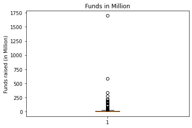

```python
#C. Plot box plot for funds in million. [1 Mark]

figure = plt.boxplot(df.Funds_in_million)
plt.title('Funds in Million')
plt.ylabel("Funds raised (in Million)")
```

```python
#D. Check the number of outliers greater than the upper fence. [1 Mark]

Q1 = np.percentile(df['Funds_in_million'], 25)
Q3 = np.percentile(df['Funds_in_million'], 75)
IQR = Q3-Q1
upper_fence = Q3 + (1.5 * IQR)
print('IQR: ',IQR.round(4))
print('Upper Fence: ',upper_fence.round(4))

outliers = df[df['Funds_in_million']> upper_fence]
outliers
```

```
IQR:  8.7297
Upper Fence:  22.5696
```

|  | Startup | Product | Funding | Event | Result | OperatingState | Funds_in_million |
| --- | --- | --- | --- | --- | --- | --- | --- |
| 6 | 8 Securities | 8securities.com | $29M | Disrupt Beijing 2011 | Finalist | Operating | 29.0 |
| 31 | Anyclip | anyclip.com | $24M | TC50 2009 | Finalist | Operating | 24.0 |
| 40 | Artsy | artsy.net | $50.9M | Disrupt NYC 2010 | Contestant | Operating | 50.9 |
| 49 | Badgeville | badgeville.com | $40M | Disrupt SF 2010 | Finalist | Acquired | 40.0 |
| 56 | Betterment | betterment.com | $205M | Disrupt NYC 2010 | Finalist | Operating | 205.0 |
| 108 | Clickable | clickable.com | $32.5M | TC40 2007 | Finalist | Acquired | 32.5 |
| 113 | Cloudflare | cloudflare.com | $182.1M | Disrupt SF 2010 | Runner up | Operating | 182.1 |
| 128 | Credit Sesame | creditsesame.com | $35.4M | Disrupt SF 2010 | Contestant | Operating | 35.4 |
| 130 | CrowdFlower Inc. | crowdflower.com | $38M | TC50 2009 | Contestant | Operating | 38.0 |
| 132 | Cubic Telecom | cubictelecom.com | $37.1M | TC40 2007 | Contestant | Operating | 37.1 |
| 138 | DataSift | datasift.com | $72M | Disrupt SF 2010 | Finalist | Operating | 72.0 |
| 139 | DataXu | dataxu.com | $64M | TC50 2009 | Contestant | Operating | 64.0 |
| 154 | Dropbox | dropbox.com | $1.7B | TC50 2008 | Contestant | Operating | 1700.0 |
| 166 | Enigma | enigma.io | $34.6M | Disrupt NYC 2013 | Winner | Operating | 34.6 |
| 172 | EverythingMe | everything.me | $35.5M | Disrupt NYC 2011 | Contestant | Closed | 35.5 |
| 179 | Famo.us | famo.us | $30.1M | Disrupt SF 2012 | Contestant | Operating | 30.1 |
| 180 | Farmigo | farmigo.com | $26M | Disrupt SF 2011 | Finalist | Operating | 26.0 |
| 188 | Fitbit | fitbit.com | $66M | TC50 2008 | Finalist | Ipo | 66.0 |
| 191 | Flock | flock.com | $28.3M | TC40 2007 | Contestant | Acquired | 28.3 |
| 209 | Getaround | getaround.com | $103M | Disrupt NYC 2011 | Winner | Operating | 103.0 |
| 213 | Gild | gild.com | $25.9M | Disrupt SF 2010 | Contestant | Acquired | 25.9 |
| 215 | Glide | glide.me | $36.5M | Disrupt NYC 2013 | Audience choice | Operating | 36.5 |
| 225 | Grockit | grockit.com | $44.7M | TC50 2008 | Finalist | Acquired | 44.7 |
| 231 | HackerRank | hackerrank.com | $24.2M | Disrupt SF 2012 | Contestant | Operating | 24.2 |
| 271 | Ionic Security | ionicsecurity.com | $122.4M | Disrupt SF 2012 | Contestant | Operating | 122.4 |
| 276 | IZEA | izea.com | $34.9M | Disrupt NYC 2010 | Contestant | Ipo | 34.9 |
| 279 | Jiff | jiff.com | $67.8M | Disrupt SF 2011 | Contestant | Acquired | 67.8 |
| 282 | Kaltura | kaltura.com | $166.1M | TC40 2007 | Audience choice | Operating | 166.1 |
| 302 | Layer | layer.com | $42.1M | Disrupt SF 2013 | Winner | Operating | 42.1 |
| 305 | LearnVest | learnvest.com | $69M | TC50 2009 | Contestant | Acquired | 69.0 |
| 313 | LiveIntent | liveintent.com | $65.1M | Disrupt NYC 2010 | Audience choice | Operating | 65.1 |
| 325 | Lystable | lystable.com | $25.1M | Disrupt London 2015 | Finalist | Operating | 25.1 |
| 346 | Mint | mint.com | $31.8M | TC40 2007 | Winner | Acquired | 31.8 |
| 389 | OrderWithMe | orderwithme.com | $37M | Disrupt Beijing 2011 | Winner | Operating | 37.0 |
| 393 | Osmo | playosmo.com | $38.5M | Disrupt SF 2013 | Contestant | Operating | 38.5 |
| 394 | Ossia | ossia.com | $25.5M | Disrupt SF 2013 | Runner up | Operating | 25.5 |
| 398 | Owlet Baby Care | owletcare.com | $24M | Hardware Battlefield 2014 | Runner up | Operating | 24.0 |
| 427 | Postmates | postmates.com | $278M | Disrupt SF 2011 | Contestant | Operating | 278.0 |
| 432 | Prism Skylabs | prism.com | $24M | Disrupt SF 2011 | Runner up | Operating | 24.0 |
| 435 | PubMatic | pubmatic.com | $63M | TC40 2007 | Contestant | Operating | 63.0 |
| 460 | Roadie | roadie.com | $25M | Disrupt NYC 2014 | Audience choice | Operating | 25.0 |
| 471 | SeatGeek | seatgeek.com | $160M | TC50 2009 | Contestant | Operating | 160.0 |
| 546 | StyleSeat | styleseat.com | $40M | Disrupt NYC 2011 | Contestant | Operating | 40.0 |
| 555 | Symphony Commerce | symphonycommerce.com | $47.4M | Disrupt NYC 2011 | Contestant | Operating | 47.4 |
| 560 | Talkdesk | talkdesk.com | $24.5M | Disrupt NYC 2012 | Contestant | Operating | 24.5 |
| 581 | TouchPal | touchpal.com | $25M | Disrupt Beijing 2011 | Finalist | Operating | 25.0 |
| 593 | TrueCar | truecar.com | $332.4M | TC50 2008 | Contestant | Ipo | 332.4 |
| 598 | UberConference | uberconference.com | $35M | Disrupt NYC 2012 | Winner | Operating | 35.0 |
| 606 | Upwork | upwork.com | $168.8M | TC50 2009 | Audience choice | Operating | 168.8 |
| 615 | VideoSurf | videosurf.com | $28M | TC50 2008 | Contestant | Acquired | 28.0 |
| 625 | Voxy | voxy.com | $30.8M | Disrupt SF 2010 | Contestant | Operating | 30.8 |
| 643 | Xobni | yahoo.com | $41.8M | TC40 2007 | Contestant | Acquired | 41.8 |
| 644 | Yammer | yammer.com | $142M | TC50 2008 | Winner | Acquired | 142.0 |
| 647 | Yext | yext.com | $117.8M | TC50 2009 | Contestant | Ipo | 117.8 |
| 649 | YouNow | younow.com | $26M | Disrupt SF 2011 | Contestant | Operating | 26.0 |
| 650 | YourMechanic | yourmechanic.com | $28M | Disrupt SF 2012 | Winner | Operating | 28.0 |
| 654 | ZEFR | zefr.com | $62.1M | Disrupt NYC 2010 | Contestant | Operating | 62.1 |
| 656 | Zenefits | zenefits.com | $583.6M | Disrupt NYC 2013 | Finalist | Operating | 583.6 |
| 659 | Zocdoc | zocdoc.com | $223M | TC40 2007 | Contestant | Operating | 223.0 |
| 661 | Zumper | zumper.com | $31.5M | Disrupt SF 2012 | Finalist | Operating | 31.5 |

```python
df.drop(df[df.Funds_in_million > upper_fence].index, inplace = True)
```

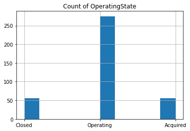

```python
#E. Check frequency of the OperatingState features classes. [1 Mark]

plt.subplots(figsize=(6,4))
plt.title('Count of OperatingState')
df.OperatingState.hist()
```

```python
df.OperatingState.value_counts()
```

```
Operating    275
Closed        56
Acquired      55
Name: OperatingState, dtype: int64
```

# 4. Statistical Analysis: [10 Marks]

```python
from scipy.stats import ttest_1samp, ttest_ind, mannwhitneyu, levene, shapiro
```

```python
#A. Is there any significant difference between Funds raised by companies that are still operating vs companies that closed down? [1 Mark]

operating_df = np.array(df[df.OperatingState == 'Operating'].Funds_in_million)
closed_df = np.array(df[df.OperatingState == 'Closed'].Funds_in_million)
```

# Using t-test

```
Null hypothesis ||H0  There is no significant difference between the means of two groups
Alternate hypothesis ||Ha  There is significantdifference between the means of two groups
```

```python
#A. Is there any significant difference between Funds raised by companies that are still operating vs companies that closed down? [1 Mark]
#B. Write the null hypothesis and alternative hypothesis. [1 Mark]
#C Test for significance and conclusion [1 Mark]

# null hypothesis H0: There is no significant difference between Funds raised | both groups have same mean
# alternate hypothesis Ha: There is a difference between Fund raised by the companies that are still operating
#vs that closed down | both groups have different mean

# level of significance is 95 %
# its a two tail test so

alpha = 0.05
t_statistic, p_value = ttest_ind(operating_df, closed_df)
print('t_statistic: ',t_statistic.round(4),'|| p_value: ', p_value.round(4))
print('')
if p_value > alpha:
    print('Accept the Null hypothesis || Both groups have same mean')
else:
    print('Reject the Null hypothesis || Both groups have different mean')
```

```
t_statistic:  1.3039 || p_value:  0.1932

Accept the Null hypothesis || Both groups have same mean
```

```python
#D. Make a copy of the original data frame. [1 Mark]

df_copy = df.copy(deep = True)
df_copy.head()
```

|  | Startup | Product | Funding | Event | Result | OperatingState | Funds_in_million |
| --- | --- | --- | --- | --- | --- | --- | --- |
| 1 | 3DLT | 3dlt.com | $630K | Disrupt NYC 2013 | Contestant | Closed | 0.63 |
| 3 | 3Dprintler | 3dprintler.com | $1M | Disrupt NY 2016 | Audience choice | Operating | 1.00 |
| 5 | 5to1 | 5to1.com | $19.3M | TC50 2009 | Contestant | Acquired | 19.30 |
| 10 | AdhereTech | adheretech.com | $1.8M | Hardware Battlefield 2014 | Contestant | Operating | 1.80 |
| 11 | AdRocket | adrocket.com | $1M | TC50 2008 | Contestant | Closed | 1.00 |

```python
#Check frequency distribution of Result variables. [1 Mark]
df_copy['Result'].value_counts()
```

```
Contestant         282
Finalist            52
Audience choice     20
Winner              17
Runner up           15
Name: Result, dtype: int64
```

```python
#F. Calculate percentage of winners that are still operating and percentage of contestants that are still operating [1 Mark]

df1 = df_copy[df_copy['OperatingState']=='Operating']
df1.Result.value_counts()
```

```
Contestant         194
Finalist            37
Audience choice     18
Runner up           14
Winner              12
Name: Result, dtype: int64
```

```python
# percentage of winners that are still operating

total_win = df_copy['Result'].value_counts()[1:].sum()
win = df1.Result.value_counts()[1:].sum()

print('Percentage of winners that are still operating is: %1.2f '%((win/total_win)*100))
```

```
Percentage of winners that are still operating is: 77.88
```

```python
# percentage of contestants that are still operating

total_cont = df_copy['Result'].value_counts()['Contestant']
cont = df1.Result.value_counts()['Contestant']

print('Percentage of contestants that are still operating is: %1.2f '%((cont/total_cont)*100))
```

```
Percentage of contestants that are still operating is: 68.79
```

```python
# G Write your hypothesis comparing the proportion of companies that are operating between winners and contestants: [2 Mark]
#H. Test for significance and conclusion [1 Mark]

# import ztest proportions package
from statsmodels.stats.proportion import proportions_ztest

# level of significance, 95 %
# so value of alpha be 0.05

alpha = 0.05
test_statistic, p_value = proportions_ztest([cont, win], [total_cont, total_win])

print('test_statistic: ',test_statistic.round(4),'|| p_value: ', p_value.round(4))
print('')
if p_value > alpha:
    print('Accept the Null hypothesis || The proportion is same for both categories')
else:
    print('Reject the Null hypothesis || The difference in proportion for both categories is significant')
```

```
test_statistic:  -1.7506 || p_value:  0.08

Accept the Null hypothesis || The proportion is same for both categories
```

```python
#I. Select only the Event that has ‘disrupt’ keyword from 2013 onwards. [1 Mark]

df['eventyear'] = df['Event'].str[-4:]
df['eventyear'].replace('-', 0,inplace=True)
df['eventyear'] = df['eventyear'].astype('int')
df.query('eventyear >= 2013 and Event.str.contains("Disrupt") ', engine='python')
```

|  | Startup | Product | Funding | Event | Result | OperatingState | Funds_in_million | eventyear |
| --- | --- | --- | --- | --- | --- | --- | --- | --- |
| 1 | 3DLT | 3dlt.com | $630K | Disrupt NYC 2013 | Contestant | Closed | 0.630 | 2013 |
| 3 | 3Dprintler | 3dprintler.com | $1M | Disrupt NY 2016 | Audience choice | Operating | 1.000 | 2016 |
| 13 | Agrilyst | agrilyst.com | $1M | Disrupt SF 2015 | Winner | Operating | 1.000 | 2015 |
| 14 | Aiden | aiden.ai | $750K | Disrupt London 2016 | Contestant | Operating | 0.750 | 2016 |
| 16 | Aircall | aircall.io | $11.6M | Disrupt SF 2015 | Contestant | Operating | 11.600 | 2015 |
| ... | ... | ... | ... | ... | ... | ... | ... | ... |
| 635 | Welltwigs | welltwigs.com | $50K | Disrupt NY 2015 | Contestant | Operating | 0.050 | 2015 |
| 641 | Workspot | workspot.com | $15.8M | Disrupt NYC 2013 | Contestant | Operating | 15.800 | 2013 |
| 642 | Xendo | xendo.com | $28K | Disrupt SF 2014 | Contestant | Acquired | 0.028 | 2014 |
| 646 | YayPay Inc | yaypay.com | $900K | Disrupt London 2015 | Contestant | Operating | 0.900 | 2015 |
| 660 | Zula | zulaapp.com | $3.4M | Disrupt SF 2013 | Audience choice | Operating | 3.400 | 2013 |

185 rows × 8 columns